# Homework # 3 - Solution

## Question 1

1. 2pts shapiro test
2. 1pt pvals
3. 2pts histogram
4. 1pt mean and median
5. 1pt why mean and median differ

### Part A

The clearest way is to write your own function first to deal with a single vector (column of iris), and then apply this function to each column using `lapply()`

```r
myFUN <- function(column) {
  if(is.numeric(column)) {
    shapiro.test(column)
  }
}

iris_results <- lapply(iris, myFUN)
iris_results
```

```
## $Sepal.Length
##
##  Shapiro-Wilk normality test
##
## data:  column
## W = 0.97609, p-value = 0.01018
##
##
## $Sepal.Width
##
##  Shapiro-Wilk normality test
##
## data:  column
## W = 0.98492, p-value = 0.1012
##
##
## $Petal.Length
##
##  Shapiro-Wilk normality test
##
## data:  column
## W = 0.87627, p-value = 7.412e-10
##
##
## $Petal.Width
##
##  Shapiro-Wilk normality test
##
## data:  column
## W = 0.90183, p-value = 1.68e-08
##
##
## $Species
## NULL
```

### Part B

This time, I write my own function, but I do it right on the same line (an inline function). It is a little harder to read, but not too bad in this simple case.

```r
pvals <- lapply(iris_results, FUN= function(result) {return(result$p.value)})
pvals
```

```
## $Sepal.Length
## [1] 0.01018116
##
## $Sepal.Width
## [1] 0.1011543
##
## $Petal.Length
## [1] 7.412263e-10
##
## $Petal.Width
## [1] 1.680465e-08
##
## $Species
## NULL
```

Alternatively, I could write the function first and then do lapply, so this is the same.

```r
getPval <- function(theList) {
  return(theList$p.value)
}

pvals <- lapply(iris_results, FUN=getPval)
pvals
```

```
## $Sepal.Length
## [1] 0.01018116
##
## $Sepal.Width
## [1] 0.1011543
##
## $Petal.Length
## [1] 7.412263e-10
##
## $Petal.Width
## [1] 1.680465e-08
##
## $Species
## NULL
```

### Part C

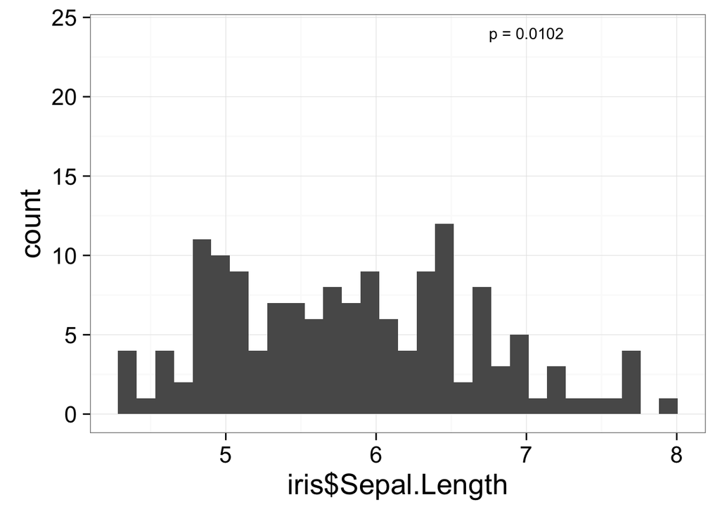

```r
library(ggplot2)
qplot(iris$Sepal.Length) + annotate("text", x=7, y=24, label=paste("p =", round(pvals$Sepal.Length, 4)))
```

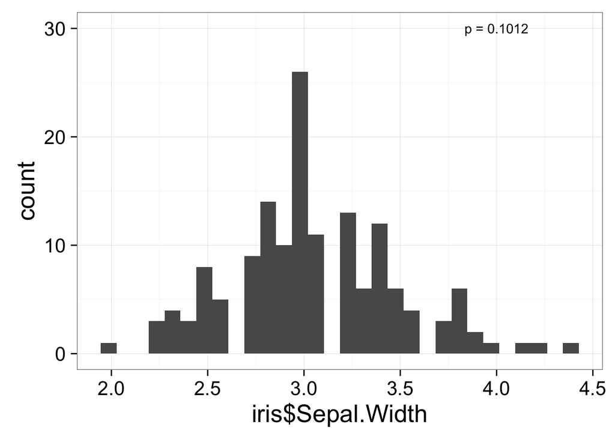

```r
qplot(iris$Sepal.Width) + annotate("text", x=4, y=30, label=paste("p =", round(pvals$Sepal.Width, 4)))
```

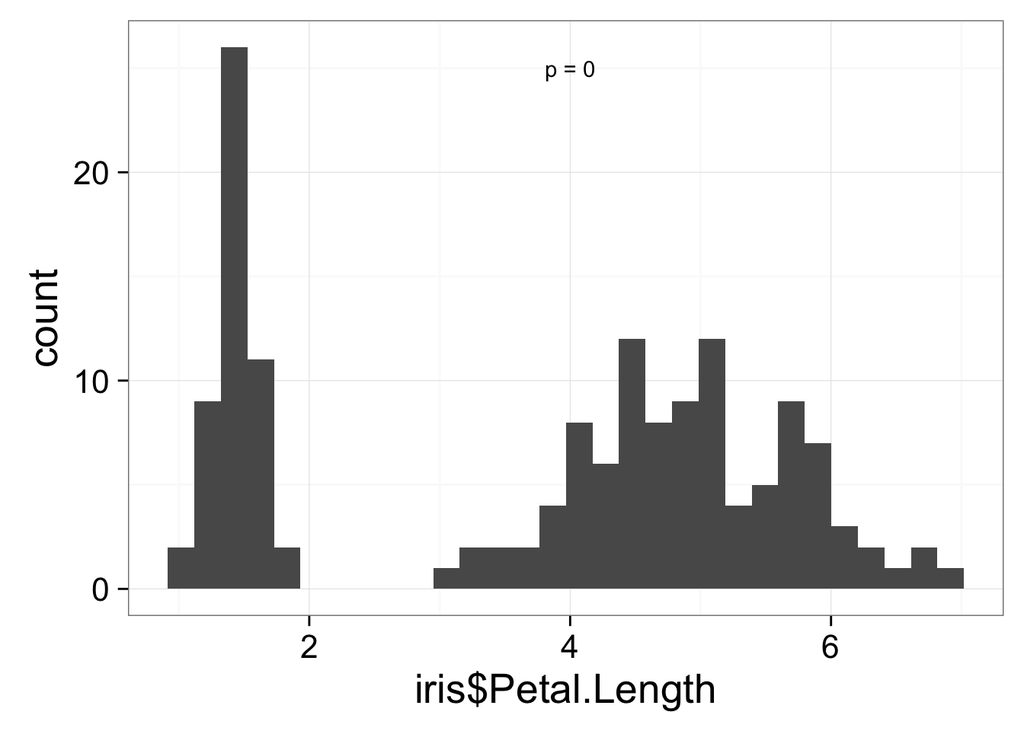

```r
qplot(iris$Petal.Length) + annotate("text", x=4, y=25, label=paste("p =", round(pvals$Petal.Length, 4)))
```

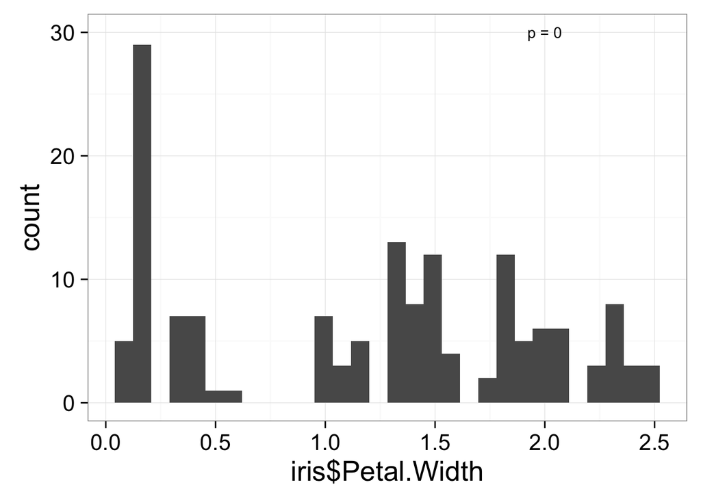

```r
qplot(iris$Petal.Width) + annotate("text", x=2, y=30, label=paste("p =", round(pvals$Petal.Width, 4)))
```

### Part D

```r
mean(iris$Sepal.Length^2)
```

```
## [1] 34.82567
```

```r
median(iris$Sepal.Length^2)
```

```
## [1] 33.64
```

### Part E

These values are different because the distribution of `iris$Sepal.Length^2` is asymmetric, as shown in the below histogram.

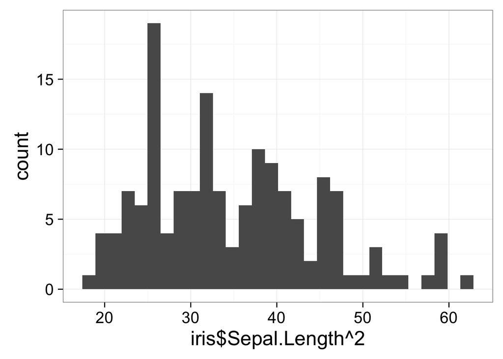

```r
qplot(iris$Sepal.Length^2)
```

The distribution has a long right tail, which heavily influences the mean, pulling it towards the larger values. The median is less affected by extreme values.

## Question 2

1. 1pt body mass vector
2. 2pts growth loop
3. 2pts vargrowth
4. 2pts environmental vargrowth
5. 2pts normality test
6. 1pt questions

### Part A

```r
body.sizes <- rnorm(1000, mean=10, sd=3)
## make a copy so we can always go back
body.sizes.original <- body.sizes
```

### Part B

```r
for(year in 1:10) {
  body.sizes <- body.sizes * 1.15
}

#save the results
body.sizes.growth <- body.sizes
```

### Part C

```r
growth.rates <- rnorm(1000, 1.15, 0.2)

#reset the body.sizes variable
body.sizes <- body.sizes.original

for(year in 1:10) {
  body.sizes <- body.sizes * growth.rates
}

body.sizes.vargrowth <- body.sizes
```

### Part D

```r
#reset the body.sizes variable
body.sizes <- body.sizes.original

for(year in 1:10) {
  body.sizes <- body.sizes * growth.rates * rnorm(1, mean=1, sd=0.2)
}

body.sizes.environmentalgrowth <- body.sizes
```

### Part E

*Note:* I made histograms too because I like them, but I didn’t ask you to.

#### Original Body sizes

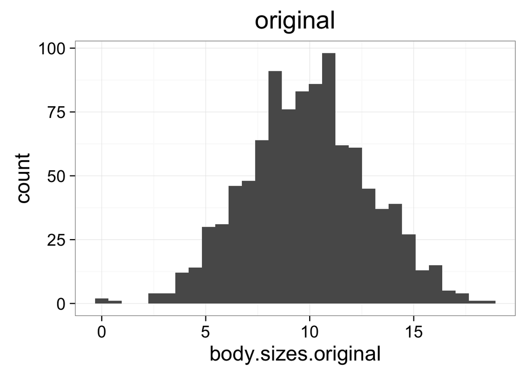

```r
qplot(body.sizes.original, main = "original")
```

```r
shapiro.test(body.sizes.original)
```

```
##
##  Shapiro-Wilk normality test
##
## data:  body.sizes.original
## W = 0.99866, p-value = 0.6613
```

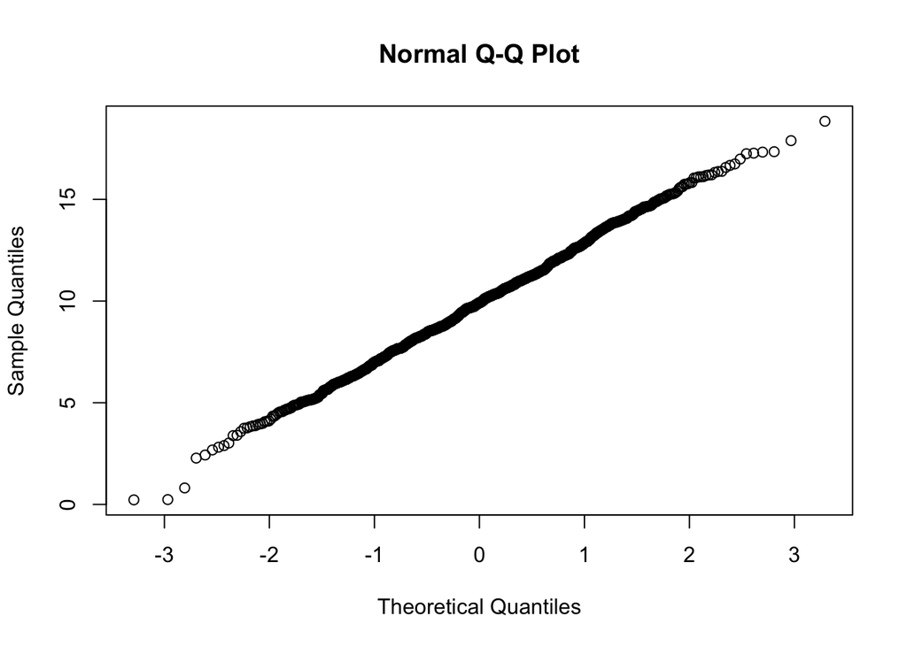

```r
qqnorm(body.sizes.original)
```

#### With simple growth rate

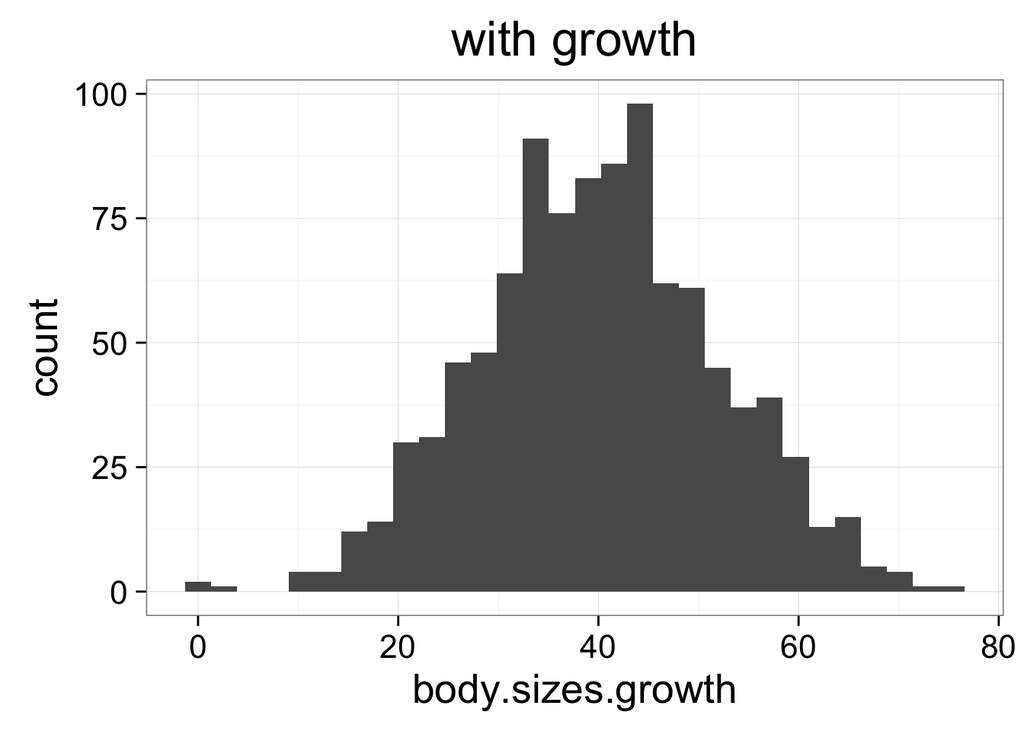

```r
qplot(body.sizes.growth, main = "with growth")
```

```r
shapiro.test(body.sizes.growth)
```

```
##
##  Shapiro-Wilk normality test
##
## data:  body.sizes.growth
## W = 0.99866, p-value = 0.6613
```

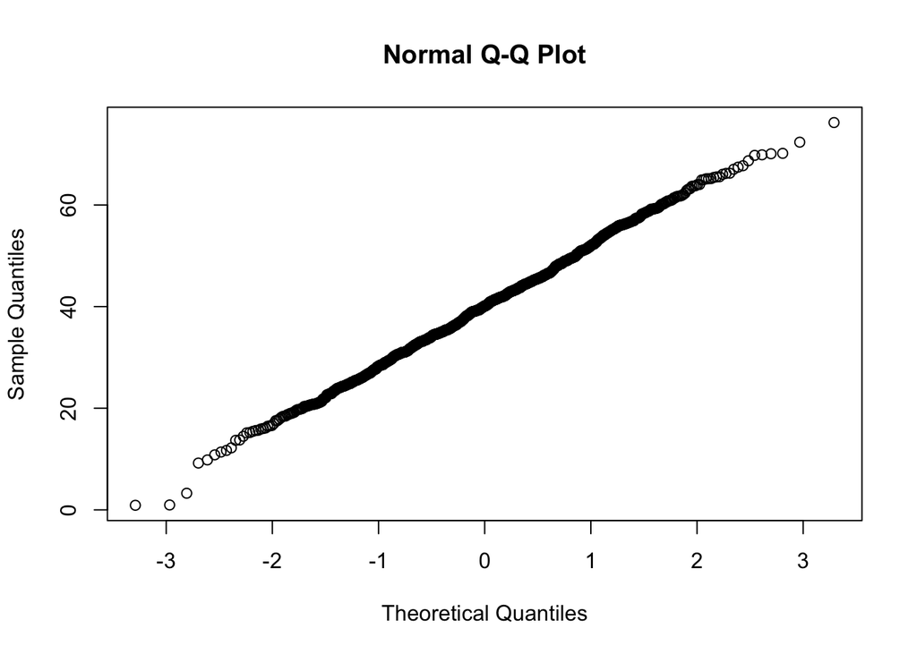

```r
qqnorm(body.sizes.growth)
```

#### With variable growth rates

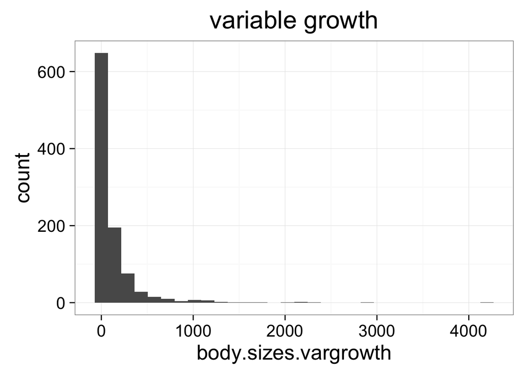

```r
qplot(body.sizes.vargrowth, main = "variable growth")
```

```r
shapiro.test(body.sizes.vargrowth)
```

```
##
##  Shapiro-Wilk normality test
##
## data:  body.sizes.vargrowth
## W = 0.43093, p-value < 2.2e-16
```

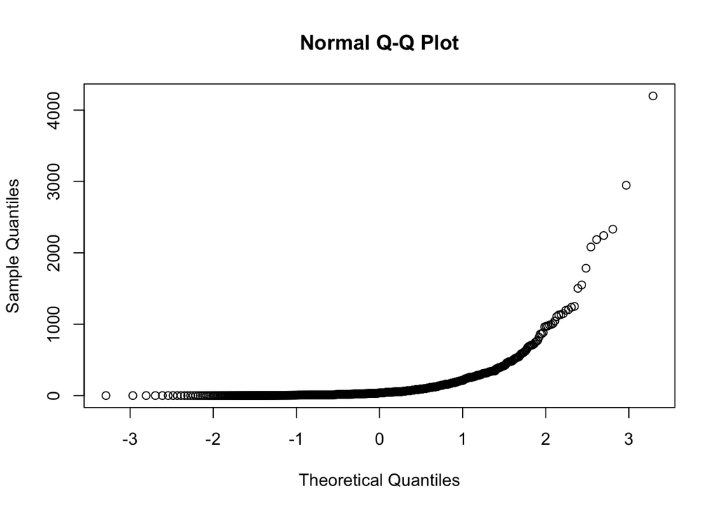

```r
qqnorm(body.sizes.vargrowth)
```

#### With variable growth rates and environmental variability year to year

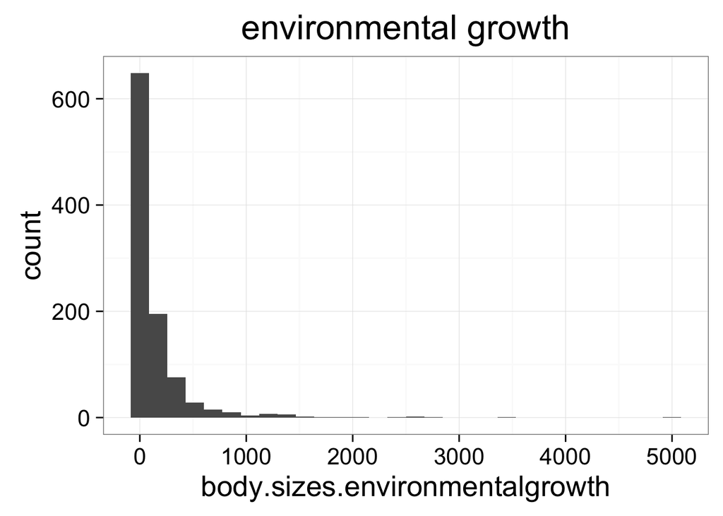

```r
qplot(body.sizes.environmentalgrowth, main = "environmental growth")
```

```r
shapiro.test(body.sizes.environmentalgrowth)
```

```
##
##  Shapiro-Wilk normality test
##
## data:  body.sizes.environmentalgrowth
## W = 0.43093, p-value < 2.2e-16
```

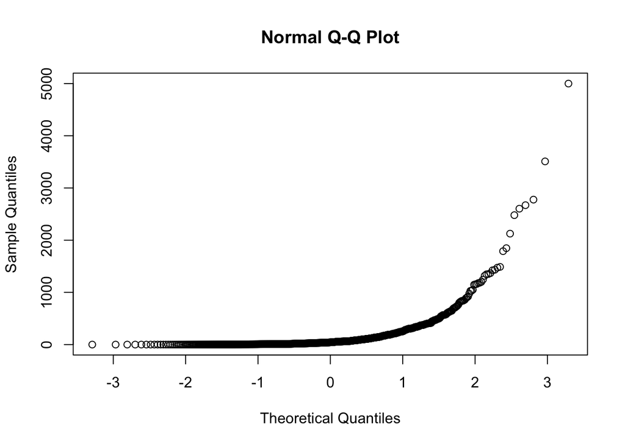

```r
qqnorm(body.sizes.environmentalgrowth)
```

### Part F

1. Does growth of a normally-distributed population lead to non-normal distributions? *No*
   2. Does variation in growth cause non-normality? *Yes*
   3. Does environmental stochasticity reduce or amplify body size variation? *It aplifies it…check out their standard deviations*